# Assignment 9: Hypothesis Testing and Power and Sample size Determination

Ramya Pinninti

## **Assignment Objectives**

- Enhance understanding the logic and procedure of hypothesis testing .
- Implement the procedures for power and sample size calculation for basic hypothesis testing procedures using nuilt-in function and manual calculation.

## **Policies of Using AI Tools**

**Policy on AI Tool Use**: Please adhere to the AI tool policy specified in the course syllabus. The direct copying of AI-generated content is strictly prohibited. All submitted work must reflect your own understanding; where external tools are consulted, content must be thoroughly rephrased and synthesized in your own words.

**Code Inclusion Requirement**: Any code included in your essay must be properly commented to explain the purpose and/or expected output of key code lines. Submitting AI-generated code without meaningful, student-added comments will not be accepted.

## **Simple versus Composite Hypothesis*

**Simple Hypothesis**

- **Simple Hypothesis Test** is a hypothesis that completely specifies the population distribution. Mathematically, simple hypothesis fixes all parameters to specific values. For example, The simple hypotheses are: $H_0: \mu = 5$ (if $\alpha$ is known), $H_0: \mu = 100, \sigma^2 = 25$, and $H_1: p = 0.7$ for a Bernoulli distribution.
- **Example Scenario** Test if a coin is fair:

$$\begin{aligned}
H_0&: p = 0.5 \quad \text{(completely specified)} \\
H_1&: p = 0.6 \quad \text{(also completely specified)}
\end{aligned}$$

Both are **simple** hypotheses.

**Composite Hypothesis**

- **Composite Hypothesis** is a hypothesis that does not completely specify the distribution. Mathematically, it allows a range of values for at least one parameter. For example, in one-sided: $\mu >5$; in two-sided: $\mu \le 5$.
- **Example Scenarios**

$$\begin{aligned}
&H_0: \mu = 5 && \text{(simple)} \\
&H_1: \mu > 5 && \text{(composite)}
\end{aligned}$$
$$\begin{aligned}
&H_0: \mu \leq 5 && \text{(composite)} \\
&H_1: \mu > 5 && \text{(composite)}
\end{aligned}$$
$$\begin{aligned}
&H_0: \text{data follows } N(\mu, 1), \mu = 0 &&
\text{(simple)} \\
&H_1: \text{data follows Poisson}(\lambda) &&
\text{(composite – different family)}
\end{aligned}$$

**This assignment focuses on performing performing a test of mean ($\mu$) a normal population and calculating the power and sample size based on various assumptions**

## **Question: New Cholesterol Medication**

A pharmaceutical company develops **“CholestFix”** to reduce Low-Density Lipoprotein (LDL, *fat carrier that’s low in density*) cholesterol. The **current standard drug** lowers LDL by an average of 25 mg/dL with a standard deviation of 15 mg/dL. A clinical trial with 5 participants were recruited in the study for three months. At the end of the study, the mean reduction is 29 mg/dL. Assume that the variance of LDL reduction of new drug is the same as that of the standard drugs.

Based on the results in the clinical trial, researchers in the company believe **CholestFix** is more effective.

a). Perform a formal hypothesis test of the researchers’ belief regarding LDL reduction, using a significance level of $\alpha = 0.05$.

**Null Hypothesis ($H_0$)**: $\mu = 25$ mg/dL (The mean LDL reduction is the same as the standard drug).

**Alternative Hypothesis ($H_a$)**: ($H_a$): $\mu > 25$ mg/dL (The mean LDL reduction is greater than 25).

**Calculation**: Test Statistic ($t$): $t = \frac{29 - 25}{15/\sqrt{5}} \approx 0.5963$ Degrees of Freedom ($df$): $5 - 1 = 4$ Critical Value ($t_{crit}$): $+2.132$ (For $\alpha = 0.05$, one-sided/upper-tail).P-value: $0.2915$

**Summary & Interpretation**: Since the calculated $t_{stat}$ ($0.5963$) is less than the critical value ($2.132$), and the $p$-value ($0.2915$) is significantly greater than $0.05$, we fail to reject the null hypothesis ($H_0$).

**Justification**: The researchers’ statement was directional, and a one-sided test is more powerful for detecting any improvement in LDL reduction. However, the observed improvement is not large enough to be significant and conclude that the drug is superior to the standard.

b). Given $n = 50, \sigma = 15, \alpha = 0.05$, and an effect size we wish to detect $\delta = 4$ mg/dL (corresponding to a reduction from 29 mg/dL to 25 mg/dL). What is the probability that we’d detect a true improvement?

Given $n = 50, \sigma = 15, \alpha = 0.05$ (one-sided), and an effect size $\delta = 4$ mg/dL:

**Power** ($\approx 58.5\%$): Using the non-central $t$-distribution for a one-sided test, the probability of rejecting $H_0$ if the true mean reduction is actually $29$ mg/dL is $0.5850$.

There is a 58.5% chance of correctly detecting that CholestFix works better if the actual improvement is 4 mg/dL.

**Justification**: While this is an improvement over the two-sided design, a $58.5\%$ power still carries a high risk (over $40\%$) of a Type II error (a “false negative”). In clinical research, this is generally considered an underpowered study.

c). Determine the minimum sample size required to detect an effect size of 4 mg/dL with a power of $1 - \beta = 0.8$ and a significance level of $\alpha = 0.05$. Assume the standard deviation of LDL reduction is 15 mg/dL.

To detect a $\delta = 4$ mg/dL difference with a power of $0.80$ and $\alpha = 0.05$ (one-sided): Required $n = 89$

The company should recruit at least $89$ participants to have an $80\%$ chance of a successful trial.

**Justification**: By focusing the test in one direction, the required sample size drops from $113$ (two-sided) to $89$ (one-sided). This makes the trial more cost-effective while maintaining the same $80\%$ threshold for reliability.

d). **Power curve**: To assess the impact of sample size on power, we can create a power function in terms of the sample size $n$ and use the remaining information from part (b). Plot the power curve by selecting a sequence of sample sizes.

In the context of this problem, power is the probability of correctly rejecting the null hypothesis ($H_0: \mu = 25$) when the new drug provides an LDL reduction $\geq 29$ mg/dL.

**The 80% Power Threshold**: The red dashed horizontal line represents the standard benchmark for clinical trials. At this level, there is an 80% chance of detecting a true treatment effect if one exists.

**The Required Sample Size ($n=89$)**: In a one-sided curve, the intersection with the $80\%$ threshold occurs earlier, at $n=89$. This indicates that the company can achieve its statistical goals with $24$ fewer participants than a two-sided test would require.

**Relationship Between $n$ and Power**:The curve shows a diminishing marginal return.In the lower ranges (e.g., moving from $n=5$ to $n=50$), the power increases quickly.

As the sample size grows larger, the curve flattens. Adding more participants beyond 89 continues to increase power toward 1.0 (100%), but at a slower rate.

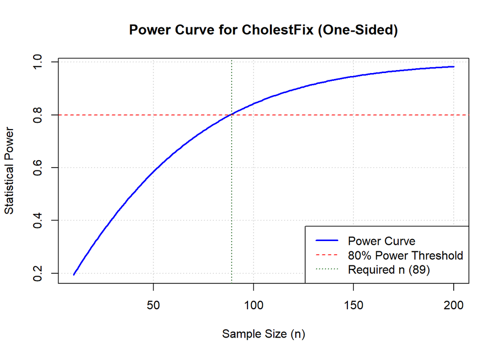

```r
delta_val <- 4
sd_val <- 15
sig_level <- 0.05

# n for a one-sided test
required_n_obj <- power.t.test(delta = delta_val,
                               sd = sd_val,
                               sig.level = sig_level,
                               power = 0.80,
                               type = "one.sample",
                               alternative = "one.sided")
required_n <- ceiling(required_n_obj$n) # 89

# 3. Power
n_sequence <- seq(10, 200, by = 1)
powers <- sapply(n_sequence, function(n) {
  power.t.test(n = n,
               delta = delta_val,
               sd = sd_val,
               sig.level = sig_level,
               type = "one.sample",
               alternative = "one.sided")$power
})

# 4. Plotting
plot(n_sequence, powers, type = "l", col = "blue", lwd = 2,
     main = "Power Curve for CholestFix (One-Sided)",
     xlab = "Sample Size (n)",
     ylab = "Statistical Power",
     panel.first = grid())

# Reference Lines
abline(h = 0.80, col = "red", lty = 2)
abline(v = required_n, col = "darkgreen", lty = 3)

# Legend
legend("bottomright",
       legend = c("Power Curve", "80% Power Threshold", paste("Required n (", required_n, ")", sep="")),
       col = c("blue", "red", "darkgreen"),
       lty = c(1, 2, 3),
       lwd = c(2, 1, 1),
       bg = "white")
```

**Note**: For each of the questions above, write a short summary of what you observed, justify why your analysis is valid, and interpret the results.